# Práctica Variable Aleatoria unidimensional

noviembre de 2017

# Descuentos

Una empresa de servicios de Internet quiere hacer una campaña para aplicar entre un 5% y un 25% de descuento a sus clientes de forma aleatoria y lineal, y entonces la probabilidad de que un cliente reciba un determinado descuento se puede modelizar mediante la siguiente función de densidad:

$$f(x) = \begin{cases} k(25 − x), & \mbox{si }\ 5 \leq \mbox{ x } \leq \ 25\\0 & \mbox{resto}\end{cases}$$

Responde a las siguientes cuestiones:

### 1. Calcula k para que f(x) sea realmente una funcion de densidad

*Para comprobar si la función f(x) es realmente una función de densidadse debe cumplir la propiedad de que la integral entre menos infinito e infinito es igual a 1.*

$$\begin{equation}
\int_{-\infty}^{\infty} f(x) \cdot dx = 1
\end{equation}$$

*Incluyendo la información del enunciado, tenemos la siguiente ecuación:*

$$\begin{equation}
\int_{5}^{25} k \ (25 - x) \cdot dx = 1
\end{equation}$$

*Despejando k:*

$$\begin{equation}
k =\frac{1}{\int_{5}^{25} \ (25 - x) \cdot dx} \
\end{equation}$$

```r
integ <- integrate(function(x) (25-x), 5, 25)$value
integ
```

```
## [1] 200
```

*Luego el valor de k es 1/200 y la función de densidad sería:*

```r
#Función de densidad
f <- function(x) (1/200)*(25-x)
```

### 2. Calcula la probabilidad de que un cliente obtenga mas de un 20% de descuento

*Teniendo la función de densidad, e incluyendo el dato del porcentaje, dicha probabilidad podría expreserase como:*

$$\begin{equation}
P[X\ > 20] \ = \int_{20}^{25} \frac{1}{200} \ (25 - x) \cdot dx
\end{equation}$$

```r
probabilidad <- integrate(f,20,25)$value
probabilidad
```

```
## [1] 0.0625
```

*La probabilidad de que un cliente obtenga más de un 20% de descuento es de* 0.0625 *, es decir, un* 6.25*%.*

### 3. ¿Cuál es el descuento medio que se espera aplicar?

*Para obtener el descuento medio, calcularemos la esperanza de la variable, definida como:*

$$\begin{equation}
E[X] = \int_{-\infty}^{\infty} x \cdot f(x) \cdot dx
\end{equation}$$

*y que una vez sustituidos los datos que tenemos quedaría como:*

$$\begin{equation}
\int_{5}^{25} x \cdot f(x) \cdot dx
\end{equation}$$

```r
esperanza <-integrate(function(x) x*f(x),5,25)$value
esperanza
```

```
## [1] 11.66667
```

*El descuento medio que se espera será de* 11.6666667*.*

### 4. Calcula la varianza de la variable aleatoria

*Definida la varianza como:*

$$\begin{equation}
Var[X] = \ E[(X- \mu)^2] = E[X^2] - E[X]^2
\end{equation}$$

*Calculamos cada una de las esperanzas con nuestros datos, obteniendo las siguientes ecuaciones:*

$$\begin{equation}
E[X^2] \Rightarrow \int_{5}^{25} x² \cdot f(x) \cdot dx
\end{equation}$$
$$\begin{equation}
E[X]^2 \Rightarrow (\int_{5}^{25} x \cdot f(x) \cdot dx)^2
\end{equation}$$

```r
Ex2<- integrate(function(x) x^2*f(x),5,25)$value
Ex_2 <- esperanza^2
varianza <- Ex2 - Ex_2
varianza
```

```
## [1] 22.22222
```

*Y obtenemos el valor de la varianza:* 22.2222222*.*

### 5. ¿Entre qué valores estarán probablemente la mitad de los descuentos realizados (en la zona central de la distribución)?

*Haciendo uso de la desigualdad de Tchebyshev que nos permite acotar la probabilidad entre dos valores utilizaremos la siguiente expresión:*

$$P \left[ \left| X - \mu \right| < k\sigma \right] \geq 1 - \dfrac{1}{k^{2}}$$

*lo que nos indica que los valores a obtener estarán representados por:*

$$\begin{equation}
\mu-\sigma k < x < \mu+\sigma k
\end{equation}$$

*Siendo sigma la desviación típica, obtenemos su valor aplicando la siguiente ecuación:*

$$\begin{equation}
Var[X] = \sigma^2 \Rightarrow \sigma = \sqrt(Var[X])
\end{equation}$$

```r
sigma <- sqrt(varianza)
```

*Dado que conocemos la función de densidad, haremos uso de ella calculando el área bajo la curva de dicha función. Dicho área, con un valor central de 0.5 como valor central la media.*

*La ecuación a aplicar sería la siguiente:*
$$\begin{equation}
0.5 = \int_{\mu-\sigma k}^{\mu+\sigma k} f(x) \cdot dx
\end{equation}$$

*y realizamos el cálculo:*

```r
k = 200 / (100*sigma - 4*sigma*esperanza)
lim_mayor <- esperanza + sigma*k
lim_menor <- esperanza - sigma*k

lim_menor
```

```
## [1] 7.916667
```

```r
lim_mayor
```

```
## [1] 15.41667
```

*El intervalo se comprende entre* 7.9166667 *y* 15.4166667.

### 6. ¿Cuál es la moda de la variable aleatoria?

*La definición de moda indica que es el valor para el cual obtenemos el máximo de la función de densidad de la V.A*

*Obtendremos dicho valor de forma gráfica:*

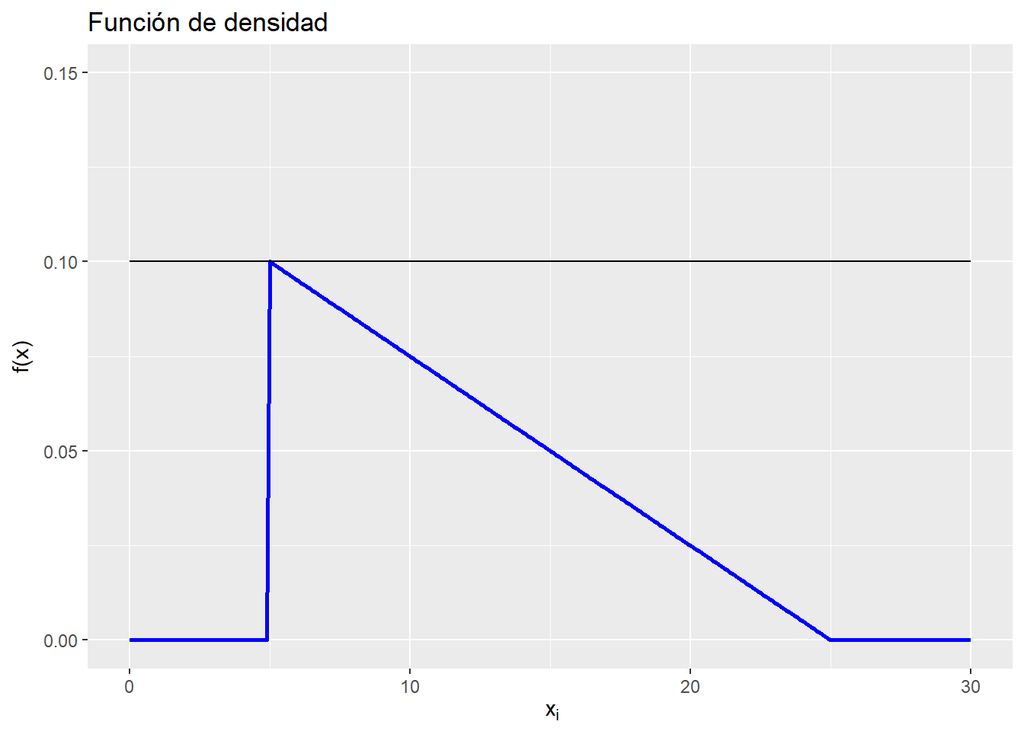

```r
# Importamos bibliotecas y datos
library(ggplot2)
#definimos un intervalo para la representación
intervalos <- 0.1
x_minimo <- 0
x_maximo <- 30
y_minimo <- 0
y_maximo <- 0.15
x_limites <-c(x_minimo,x_maximo)
y_limites <-c(y_minimo,y_maximo)

#Creamo la lista de intervalos
seq_valores <- seq(x_minimo, x_maximo, by = intervalos)

#Aplicamos función densidad a todo el intervalo
seq_valores_func <- sapply(seq_valores,f)

#Introducimos los ceros en los intervalos fuera del rango definido en los datos(5 -25)
seq_valores_func[((0/intervalos)+1):((5/intervalos))] <- 0
seq_valores_func[((25/intervalos)+1):((30/intervalos)+1)] <- 0

#Creamos DF
valores <- data.frame(valores_x = seq_valores, f_x= seq_valores_func)

#el grafico de la función de densidad
f_densidad <- ggplot(valores, aes(valores_x)) +
  geom_line(aes(y = f_x), colour = "blue", size = 1) +
  lims(x = x_limites, y = y_limites) +
  ggtitle("Función de densidad") +
  ylab("f(x)") +  xlab(bquote(~x[i]))

#para la representación del máximo
valor_max <- max(valores$f_x)
valores <- data.frame(valores, max_func = valor_max)

f_densidad +
  geom_line(aes(y = valores$max_func))
```

*El valor que nos da el máximo y por tanto valor de la moda, sería el 5.*

*Para validar el dato, comprobaremos el resultado en los datos calculados*

```r
pos_vmax <- which(valores$f_x == valor_max)
moda <- valores$valores_x[pos_vmax]
moda
```

```
## [1] 5
```

### 7. Calcula la mediana de la variable aleatoria

*Partiendo la función de distribución:*

$$\begin{equation}
F(x) = \int_{5}^{x} \frac{1}{200}\ (25 - x) \cdot dx
\end{equation}$$

*para calcular cualquier percentil, tenemos que calcular la función inversa de a Fx.* *Al tener una función de segundo grado, hay dos posibles valores de x, y dos funciones válidas:*

$$\begin{equation}
F^{-1}(p) = \frac{0.125 + \sqrt((-0.125)^2 - 4 * 0.0025 *(0.5625+x) ) }{0.005}
\end{equation}$$

$$\begin{equation}
F^{-1}(p) = \frac{0.125 - \sqrt((-0.125)^2 - 4 * 0.0025 *(0.5625+x) ) }{0.005}
\end{equation}$$

```r
Fx_inv <- function(x)
{
  sol1_pos <- (0.125 + (sqrt(((-0.125)^2) - (4*(0.0025)*(0.5625+x)))))/0.005
  sol2_neg <- (0.125 - (sqrt(((-0.125)^2) - (4*(0.0025)*(0.5625+x)))))/0.005
  Fx_result <- c(sol1_pos, sol2_neg)
  Fx_result
}
```

*Una vez obtenida la función inversa, podremos calcular el percentil 50, que corresponde a la mediana.*

```r
mediana <- sapply(0.5,Fx_inv)
mediana
```

```
##          [,1]
## [1,] 39.14214
## [2,] 10.85786
```

*Los dos posibles valores, obtenidos en la mediana son* 39.1421356 *y* 10.8578644*.*

*Dado que nuestra función estaba acotada entre 5 y 25, la mediana será* 10.8578644 *.*